# ggplot2 tutorial

### 主题

主题可以让我们控制这些图的整体外观。`theme`函数中的选项可以让我们调整字体、背景、颜色和网格线等。主题可以使用一次，也可以保存起来应用到多个图中。

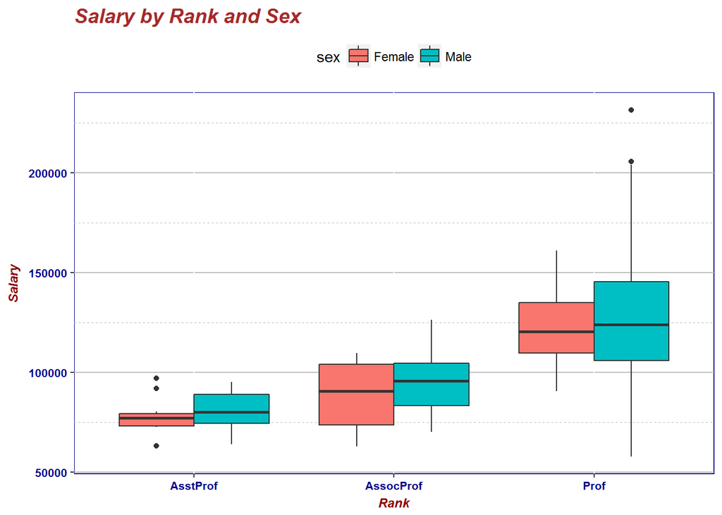

```r
mytheme <- theme (plot.title = element_text(face = "bold.italic", size = "14", color = "brown"),
                  axis.title = element_text(face = "bold.italic", size = "9", color = "darkred"),
                  axis.text = element_text(face = "bold", size = "8", color = "darkblue"),
                  panel.background = element_rect(fill = "white",color = "darkblue"),
                  panel.grid.major.y = element_line(color = "grey",linetype = 1),
                  panel.grid.minor.y = element_line(color = "grey",linetype = 2),
                  panel.grid.minor.x = element_blank(),
                  legend.position = "top")

ggplot(Salaries, aes(x = rank, y =salary, fill = sex)) + geom_boxplot() +
  labs(title = "Salary by Rank and Sex",x = "Rank", y = "Salary") +
  mytheme
```

主题指定了图的标题应该为粗斜体棕色14号字，轴的标题为粗斜体深红色9号字。坐标轴为加粗的深蓝色8号字。画图区域有白色的填充和深蓝色的边框。主水平网格应该是灰色的实线，次水平网为灰色的虚线；垂直网格不输出；图例显示在图顶部。可以查看`help(theme)`获得更多信息。

### 多重图

将多个图形放到单给图形中的最简单方法是使用gridExtra包里的`grid.arrange()`

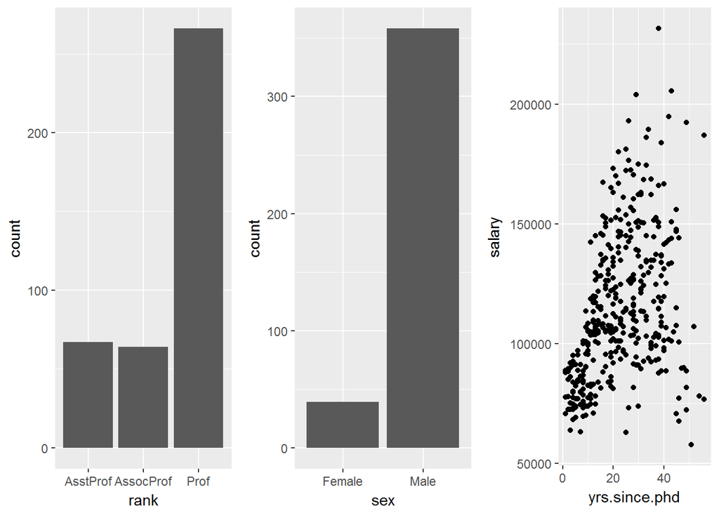

```r
p1 <- ggplot(data = Salaries, aes(x = rank)) + geom_bar()
p2 <- ggplot(data = Salaries, aes(x = sex)) + geom_bar()
p3 <- ggplot(data = Salaries, aes(x = yrs.since.phd, y = salary)) + geom_point()

library("gridExtra")
grid.arrange(p1, p2, p3, ncol = 3)
```

### 保存图形

```
p3 <- ggplot(data = Salaries, aes(x = yrs.since.phd)) + geom_point()
ggsave(file = "p3.png", plot = p3, width = 5, height = 4)
```

width和height的单位为inch，可以自由设定文件的拓展名来保存不同的形式